# 项目：TMDb电影数据调查分析

## 目录

- 简介
- 数据整理
- 探索性数据分析
- 结论

## 简介

> 本数据集中包含 1 万条电影信息，信息来源为“电影数据库”（TMDb，The Movie Database），包括用户评分、票房、“演职人员 (cast)”、“电影类别 (genres)”等数据。本次将探索两个问题：1.每年最受欢迎的电影类型是什么？2.电影的评分和人气对电影票房有什么影响

```python
# 用这个框对你计划使用的所有数据包进行设置
#   导入语句。
import pandas as pd
import matplotlib.pyplot as plt
import seaborn as sns
% matplotlib inline
# 务必包含一个‘magic word’，以便将你的视图
#   与 notebook 保持一致。关于更多信息，请访问该网页：
#   http://ipython.readthedocs.io/en/stable/interactive/magics.html
```

## 数据整理

### 常规属性

```python
# 加载数据并打印几行。进行这几项操作，来检查数据
#   类型，以及是否有缺失数据或错误数据的情况。
df = pd.read_csv('tmdb-movies.csv')
df.head()
```

|  | id | imdb_id | popularity | budget | revenue | original_title | cast | homepage | director | tagline | ... | overview | runtime | genres | production_companies | release_date | vote_count | vote_average | release_year | budget_adj | revenue_adj |
| --- | --- | --- | --- | --- | --- | --- | --- | --- | --- | --- | --- | --- | --- | --- | --- | --- | --- | --- | --- | --- | --- |
| 0 | 135397 | tt0369610 | 32.985763 | 150000000 | 1513528810 | Jurassic World | Chris Pratt\|Bryce Dallas Howard\|Irrfan Khan\|Vi... | http://www.jurassicworld.com/ | Colin Trevorrow | The park is open. | ... | Twenty-two years after the events of Jurassic ... | 124 | Action\|Adventure\|Science Fiction\|Thriller | Universal Studios\|Amblin Entertainment\|Legenda... | 6/9/15 | 5562 | 6.5 | 2015 | 1.379999e+08 | 1.392446e+09 |
| 1 | 76341 | tt1392190 | 28.419936 | 150000000 | 378436354 | Mad Max: Fury Road | Tom Hardy\|Charlize Theron\|Hugh Keays-Byrne\|Nic... | http://www.madmaxmovie.com/ | George Miller | What a Lovely Day. | ... | An apocalyptic story set in the furthest reach... | 120 | Action\|Adventure\|Science Fiction\|Thriller | Village Roadshow Pictures\|Kennedy Miller Produ... | 5/13/15 | 6185 | 7.1 | 2015 | 1.379999e+08 | 3.481613e+08 |
| 2 | 262500 | tt2908446 | 13.112507 | 110000000 | 295238201 | Insurgent | Shailene Woodley\|Theo James\|Kate Winslet\|Ansel... | http://www.thedivergentseries.movie/#insurgent | Robert Schwentke | One Choice Can Destroy You | ... | Beatrice Prior must confront her inner demons ... | 119 | Adventure\|Science Fiction\|Thriller | Summit Entertainment\|Mandeville Films\|Red Wago... | 3/18/15 | 2480 | 6.3 | 2015 | 1.012000e+08 | 2.716190e+08 |
| 3 | 140607 | tt2488496 | 11.173104 | 200000000 | 2068178225 | Star Wars: The Force Awakens | Harrison Ford\|Mark Hamill\|Carrie Fisher\|Adam D... | http://www.starwars.com/films/star-wars-episod... | J.J. Abrams | Every generation has a story. | ... | Thirty years after defeating the Galactic Empi... | 136 | Action\|Adventure\|Science Fiction\|Fantasy | Lucasfilm\|Truenorth Productions\|Bad Robot | 12/15/15 | 5292 | 7.5 | 2015 | 1.839999e+08 | 1.902723e+09 |
| 4 | 168259 | tt2820852 | 9.335014 | 190000000 | 1506249360 | Furious 7 | Vin Diesel\|Paul Walker\|Jason Statham\|Michelle ... | http://www.furious7.com/ | James Wan | Vengeance Hits Home | ... | Deckard Shaw seeks revenge against Dominic Tor... | 137 | Action\|Crime\|Thriller | Universal Pictures\|Original Film\|Media Rights ... | 4/1/15 | 2947 | 7.3 | 2015 | 1.747999e+08 | 1.385749e+09 |

5 rows × 21 columns

```python
# 检查数据
df.info()
```

```
<class 'pandas.core.frame.DataFrame'>
RangeIndex: 10866 entries, 0 to 10865
Data columns (total 21 columns):
id                      10866 non-null int64
imdb_id                 10856 non-null object
popularity              10866 non-null float64
budget                  10866 non-null int64
revenue                 10866 non-null int64
original_title          10866 non-null object
cast                    10790 non-null object
homepage                2936 non-null object
director                10822 non-null object
tagline                 8042 non-null object
keywords                9373 non-null object
overview                10862 non-null object
runtime                 10866 non-null int64
genres                  10843 non-null object
production_companies    9836 non-null object
release_date            10866 non-null object
vote_count              10866 non-null int64
vote_average            10866 non-null float64
release_year            10866 non-null int64
budget_adj              10866 non-null float64
revenue_adj             10866 non-null float64
dtypes: float64(4), int64(6), object(11)
memory usage: 1.7+ MB
```

```python
# 检查重复行
sum(df.duplicated())
```

```
1
```

```python
# 查看数据集维度
df.shape
```

```
(10866, 21)
```

### 清理数据集中的重复行和缺失值

```python
# 在讨论数据结构和需要解决的任何问题之后，
#   在本部分的第二小部分进行这些清理步骤。
# 查看每个特征缺失值数量
df.isnull().sum()
```

```
id                         0
imdb_id                   10
popularity                 0
budget                     0
revenue                    0
original_title             0
cast                      76
homepage                7930
director                  44
tagline                 2824
keywords                1493
overview                   4
runtime                    0
genres                    23
production_companies    1030
release_date               0
vote_count                 0
vote_average               0
release_year               0
budget_adj                 0
revenue_adj                0
dtype: int64
```

```python
# 删除homepage等缺失值较多的列
df.drop(['homepage', 'tagline', 'keywords', 'production_companies'], axis =1, inplace = True)
```

```python
# 丢弃缺失值
df.dropna(inplace= True)
```

```python
# 确认缺失值
df.isnull().sum()
```

```
id                0
imdb_id           0
popularity        0
budget            0
revenue           0
original_title    0
cast              0
director          0
overview          0
runtime           0
genres            0
release_date      0
vote_count        0
vote_average      0
release_year      0
budget_adj        0
revenue_adj       0
dtype: int64
```

```python
# 丢弃重复行
df.drop_duplicates(inplace = True)
```

```python
# 重新确认数据集维度
df.shape
```

```
(10724, 17)
```

## 探索性数据分析

> **提示**在你完成数据整理和清理之后，现在可以进行探索性数据分析了。你需要计算统计值，创建可视化图表，解决你在一开始的简介部分中提出的研究问题。我们推荐你采用系统化方法。一次只探索一个变量，然后探索变量之间的关系。

### 研究问题1:每年最受欢迎的电影类别是哪些？

> 为了探索这个问题，需将每年度的各类型电影的受欢迎程度分别统计，从愿数据集中提取数据，以sum_of_popularity,genres，release_year为新数据集的列，并进行可视化展示。

```python
# 创建研究问题1的数据集副本df_q1
df_q1 = df.copy()
# 筛选出genres中包含‘|’的列
df_genres = df[df['genres'].str.contains('|')]
```

```python
# 将genres的值按‘|’分割并生成新的DataFrame
df_all_genres = df_genres['genres'].str.split('|', expand = True)
df_all_genres.head()
```

|  | 0 | 1 | 2 | 3 | 4 |
| --- | --- | --- | --- | --- | --- |
| 0 | Action | Adventure | Science Fiction | Thriller | None |
| 1 | Action | Adventure | Science Fiction | Thriller | None |
| 2 | Adventure | Science Fiction | Thriller | None | None |
| 3 | Action | Adventure | Science Fiction | Fantasy | None |
| 4 | Action | Crime | Thriller | None | None |

```python
# 创建副本
df0 = df_genres.copy()
df1 = df_genres.copy()
df2 = df_genres.copy()
df3 = df_genres.copy()
df4 = df_genres.copy()
```

```python
# 对每个副本的genres列重新赋值
df0['genres'] = df_all_genres[0]
df1['genres'] = df_all_genres[1]
df2['genres'] = df_all_genres[2]
df3['genres'] = df_all_genres[3]
df4['genres'] = df_all_genres[4]
```

```python
# 合并所有副本，并替换df_q1中所有包含’|‘的genres
frames = [df0,df1,df2,df3,df4]
df_new = pd.concat(frames)
df_q1.drop(df_genres.index, inplace = True)
df_q1 = df_q1.append(df_new, ignore_index = True)
```

```python
# 丢弃缺失值
df_q1 = df_q1.dropna()
```

```python
# 按genres和release_year的分组将popularity求和
df_q1 = df_q1.groupby(['genres','release_year'], as_index = False)['popularity'].sum()
df_q1.head()
```

|  | genres | release_year | popularity |
| --- | --- | --- | --- |
| 0 | Action | 1960 | 4.725796 |
| 1 | Action | 1961 | 2.561389 |
| 2 | Action | 1962 | 5.671563 |
| 3 | Action | 1963 | 3.806916 |
| 4 | Action | 1964 | 4.065433 |

```python
# 按release_year的分组筛选出popularity的最大值
df_q1 = df_q1.groupby('release_year',as_index = False).apply(lambda x: x[x['popularity'] == x['popularity'].max()])
# 将popularity重命名sum_of_popularity
df_q1.rename(index = str, columns = {'popularity' : 'sum_of_popularity'}, inplace = True)
```

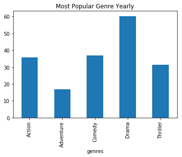

```python
# 对结果进行可视化，形成柱状图
df_q1.groupby(['genres'])['sum_of_popularity'].mean().plot(kind = 'bar');
plt.title('Most Popular Genre Yearly');
```

### 研究问题 2：电影的人气、评分对票房收入有没有影响？

> 答案：从以下两张散点图可以看出，电影的人气、评分与票房收入呈正相关。

```python
# 创建副本
df_q2 = df.copy()
```

```python
# 筛选出票房和预算不为0的数据
df_q2 = df_q2[(df_q2['budget']>0)&(df_q2['revenue']>0)&(df_q2['budget_adj']>0)&(df_q2['revenue_adj']>0)]
```

```python
# 选定popularity,vote_average,revenue_adj,budget,budget_adj,revenue五列
df_q2 = df_q2[['popularity','vote_average','revenue_adj','budget','budget_adj','revenue']]
df_q2.head()
```

|  | popularity | vote_average | revenue_adj | budget | budget_adj | revenue |
| --- | --- | --- | --- | --- | --- | --- |
| 0 | 32.985763 | 6.5 | 1.392446e+09 | 150000000 | 1.379999e+08 | 1513528810 |
| 1 | 28.419936 | 7.1 | 3.481613e+08 | 150000000 | 1.379999e+08 | 378436354 |
| 2 | 13.112507 | 6.3 | 2.716190e+08 | 110000000 | 1.012000e+08 | 295238201 |
| 3 | 11.173104 | 7.5 | 1.902723e+09 | 200000000 | 1.839999e+08 | 2068178225 |
| 4 | 9.335014 | 7.3 | 1.385749e+09 | 190000000 | 1.747999e+08 | 1506249360 |

```python
#查看描述性统计
df_q2.describe()
```

|  | popularity | vote_average | revenue_adj | budget | budget_adj | revenue |
| --- | --- | --- | --- | --- | --- | --- |
| count | 3849.000000 | 3849.000000 | 3.849000e+03 | 3.849000e+03 | 3.849000e+03 | 3.849000e+03 |
| mean | 1.192933 | 6.168693 | 1.372313e+08 | 3.724886e+07 | 4.429360e+07 | 1.078148e+08 |
| std | 1.475622 | 0.794697 | 2.162018e+08 | 4.221699e+07 | 4.481360e+07 | 1.766175e+08 |
| min | 0.001117 | 2.200000 | 2.370705e+00 | 1.000000e+00 | 9.693980e-01 | 2.000000e+00 |
| 25% | 0.463337 | 5.700000 | 1.843023e+07 | 1.000000e+07 | 1.316623e+07 | 1.367069e+07 |
| 50% | 0.798582 | 6.200000 | 6.181393e+07 | 2.400000e+07 | 3.005030e+07 | 4.490726e+07 |
| 75% | 1.374300 | 6.700000 | 1.634115e+08 | 5.000000e+07 | 6.076720e+07 | 1.243052e+08 |
| max | 32.985763 | 8.400000 | 2.827124e+09 | 4.250000e+08 | 4.250000e+08 | 2.781506e+09 |

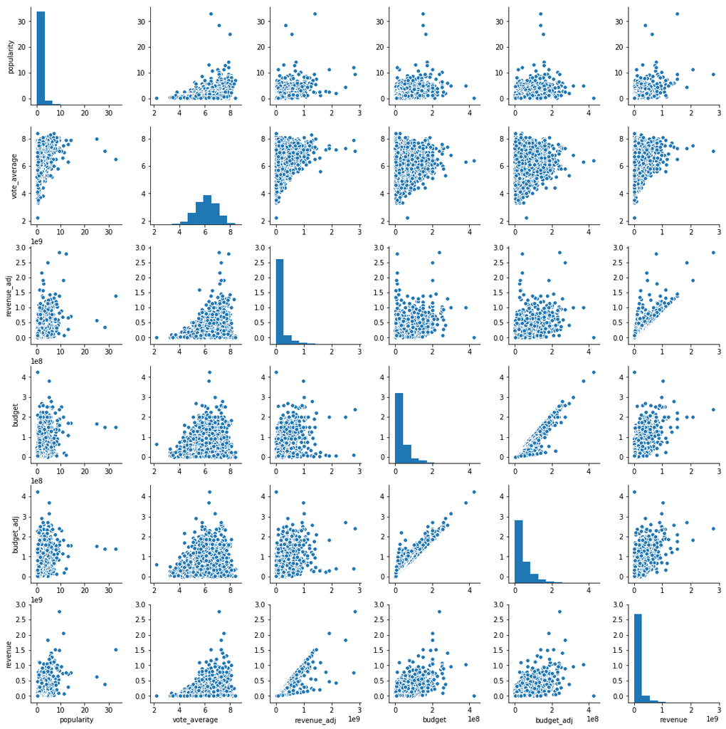

```python
sns.pairplot(df_q2);
```

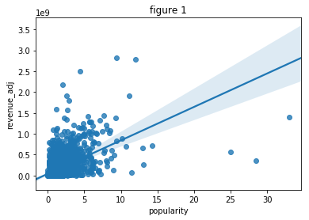

```python
# 进行可视化作出散点图
ax1 = sns.regplot(x = df_q2['popularity'], y = df_q2['revenue_adj']);
ax1.set_title('figure 1');
```

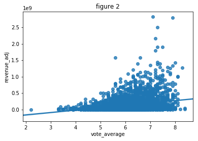

```python
ax2= sns.regplot(x = df_q2['vote_average'], y = df_q2['revenue_adj']);
ax2.set_title('figure 2');
```

## 结论

> 如需将报告导出到工作区，你可以运行下面的代码框。如果正确，会返回代码 0，工作区目录下会生成 .html 文件（单击左上角的 jupyter 图标）。也可以通过 **文件** > **下载为** 子菜单下载 html 报告，然后手动上传到工作区目录。完成之后，可以单击右下角的“提交项目”，来提交你的项目。恭喜你！

```python
from subprocess import call
call(['python', '-m', 'nbconvert', 'Investigate_a_Dataset.ipynb'])
```

```
255
```